# Project 1: Wrangling, Exploration, Visualization

SDS322E

## Data Wrangling, Exploration, Visualization

### Joshua Nahm (jkn557)

#### Introduction

One of the most troubling and often ignored issues in our world are the rising CO2 levels in our earth’s atmosphere. It is surmised that more industrialized and developed countries often emit the most CO2 emissions. I am interested in this topic because I believe that climate change should be of greater importance in our society. This project compares various countries’ carbon dioxide emissions in tons, yearly change of CO2 emissions from 2015 to 2016 in tons, and their level of development through their GDP per capita and life expectancy. Such datasets were obtained via Kaggle and Gapminder. I expect to see positive trends between population and CO2 emissions and potentially negative trends between life expectancy and CO2 emissions.

```r
# read your datasets in here, e.g., with read_csv()
library(tidyverse)
library(knitr)
library(ggplot2)
emissions <- read_csv("CO2Life.csv")
gdp <- read_csv("incomegdp.csv")
```

#### Tidying: Reshaping

If your datasets are tidy already, demonstrate that you can reshape data with pivot wider/longer here (e.g., untidy and then retidy). Alternatively, it may be easier to wait until the wrangling section so you can reshape your summary statistics. Note here if you are going to do this.

```r
# your tidying code (if applicable; can also wait until
# wrangling section)
```

The tidying will be performed in the wrangling section when reshaping the summary statistics.

#### Joining/Merging

```r
# your joining code
joined_data <- inner_join(emissions, gdp)
glimpse(emissions)
```

```
## Rows: 208
## Columns: 7
## $ Country        <chr> "Afghanistan", "Albania", "Algeria", "Angola", "Anguil…
## $ Code           <chr> "AFG", "ALB", "DZA", "AGO", "AIA", "ATG", "ARG", "ARM"…
## $ CO2Emissions   <dbl> 9900004, 5208319, 156220560, 30566933, 30262, 438763, …
## $ YearlyChange   <dbl> 7.13, 4.45, 0.17, 3.13, 1.52, 1.51, 0.16, 3.06, 1.51, …
## $ Percapita      <dbl> 0.28, 1.80, 3.85, 1.06, 2.10, 4.64, 4.61, 1.57, 2.74, …
## $ Population     <dbl> 35383032, 2886438, 40551392, 28842489, 14429, 94527, 4…
## $ LifeExpectancy <dbl> 63.763, 78.194, 76.298, 59.925, 81.441, 76.617, 76.221…
```

```r
emissions %>% distinct(Country)
```

```
## # A tibble: 208 x 1
##    Country
##    <chr>
##  1 Afghanistan
##  2 Albania
##  3 Algeria
##  4 Angola
##  5 Anguilla
##  6 Antigua and Barbuda
##  7 Argentina
##  8 Armenia
##  9 Aruba
## 10 Australia
## # … with 198 more rows
```

```r
# glimpse(gdp) --> not included because of size of data frame
gdp %>% distinct(Country)
```

```
## # A tibble: 195 x 1
##    Country
##    <chr>
##  1 Afghanistan
##  2 Angola
##  3 Albania
##  4 Andorra
##  5 United Arab Emirates
##  6 Argentina
##  7 Armenia
##  8 Antigua and Barbuda
##  9 Australia
## 10 Austria
## # … with 185 more rows
```

```r
anti_join(emissions, gdp)
```

```
## # A tibble: 32 x 7
##    Country   Code  CO2Emissions YearlyChange Percapita Population LifeExpectancy
##    <chr>     <chr>        <dbl>        <dbl>     <dbl>      <dbl>          <dbl>
##  1 Anguilla  AIA          30262         1.52      2.1       14429           81.4
##  2 Aruba     ABW         286871         1.51      2.74     104872           75.9
##  3 Bermuda   BMU         639352         1.51     10.1       63362           82.2
##  4 British … VGB          99762         1.51      3.4       29355           78.6
##  5 Cayman I… CYM         406057         1.52      6.49      62569           83.5
##  6 Congo     COG        5212302         1.63      1.05    4980996           63.6
##  7 Cook Isl… COK          37354         7.19      2.13      17524           75.6
##  8 Czech Re… CZE      111825428         1.39     10.5    10618857           78.9
##  9 Faeroe I… FRO           1953         0.6       0.04      48173           80.3
## 10 Falkland… FLK          48568         1.51     16.6        2928           81.0
## # … with 22 more rows
```

```r
anti_join(gdp, emissions)
```

```
## # A tibble: 19 x 252
##    Country `1799` `1800` `1801` `1802` `1803` `1804` `1805` `1806` `1807` `1808`
##    <chr>    <dbl>  <dbl>  <dbl>  <dbl>  <dbl>  <dbl>  <dbl>  <dbl>  <dbl>  <dbl>
##  1 Andorra   1340   1340   1340   1350   1350   1350   1350   1360   1360   1360
##  2 Congo,…    542    544    547    549    551    553    556    558    560    562
##  3 Congo,…    643    644    646    648    650    652    654    655    657    660
##  4 Czech …   2140   2140   2140   2140   2140   2140   2140   2140   2140   2140
##  5 Micron…    579    579    579    580    580    580    581    581    581    582
##  6 Hong K…   1130   1140   1150   1160   1170   1170   1180   1190   1200   1210
##  7 Kyrgyz…    568    568    568    568    568    568    569    569    569    569
##  8 St. Ki…   1300   1300   1300   1300   1300   1300   1300   1300   1300   1300
##  9 Lao        966    967    967    967    967    967    967    967    968    968
## 10 St. Lu…    977    978    978    978    978    978    978    978    978    979
## 11 Monaco    2180   2180   2180   2190   2190   2190   2200   2200   2200   2200
## 12 Marsha…    603    603    604    604    604    605    605    605    606    606
## 13 Nauru      619    619    619    619    619    619    619    619    621    621
## 14 Palest…    754    754    754    754    754    755    755    755    755    755
## 15 San Ma…   1570   1570   1570   1580   1580   1580   1580   1590   1590   1590
## 16 Sao To…    950    953    954    956    958    959    962    963    965    967
## 17 Slovak…   1600   1600   1600   1600   1600   1600   1600   1600   1600   1600
## 18 Tuvalu     804    804    804    804    804    804    804    804    804    804
## 19 St. Vi…    937    937    937    937    937    938    938    938    938    938
## # … with 241 more variables: `1809` <dbl>, `1810` <dbl>, `1811` <dbl>,
## #   `1812` <dbl>, `1813` <dbl>, `1814` <dbl>, `1815` <dbl>, `1816` <dbl>,
## #   `1817` <dbl>, `1818` <dbl>, `1819` <dbl>, `1820` <dbl>, `1821` <dbl>,
## #   `1822` <dbl>, `1823` <dbl>, `1824` <dbl>, `1825` <dbl>, `1826` <dbl>,
## #   `1827` <dbl>, `1828` <dbl>, `1829` <dbl>, `1830` <dbl>, `1831` <dbl>,
## #   `1832` <dbl>, `1833` <dbl>, `1834` <dbl>, `1835` <dbl>, `1836` <dbl>,
## #   `1837` <dbl>, `1838` <dbl>, `1839` <dbl>, `1840` <dbl>, `1841` <dbl>,
## #   `1842` <dbl>, `1843` <dbl>, `1844` <dbl>, `1845` <dbl>, `1846` <dbl>,
## #   `1847` <dbl>, `1848` <dbl>, `1849` <dbl>, `1850` <dbl>, `1851` <dbl>,
## #   `1852` <dbl>, `1853` <dbl>, `1854` <dbl>, `1855` <dbl>, `1856` <dbl>,
## #   `1857` <dbl>, `1858` <dbl>, `1859` <dbl>, `1860` <dbl>, `1861` <dbl>,
## #   `1862` <dbl>, `1863` <dbl>, `1864` <dbl>, `1865` <dbl>, `1866` <dbl>,
## #   `1867` <dbl>, `1868` <dbl>, `1869` <dbl>, `1870` <dbl>, `1871` <dbl>,
## #   `1872` <dbl>, `1873` <dbl>, `1874` <dbl>, `1875` <dbl>, `1876` <dbl>,
## #   `1877` <dbl>, `1878` <dbl>, `1879` <dbl>, `1880` <dbl>, `1881` <dbl>,
## #   `1882` <dbl>, `1883` <dbl>, `1884` <dbl>, `1885` <dbl>, `1886` <dbl>,
## #   `1887` <dbl>, `1888` <dbl>, `1889` <dbl>, `1890` <dbl>, `1891` <dbl>,
## #   `1892` <dbl>, `1893` <dbl>, `1894` <dbl>, `1895` <dbl>, `1896` <dbl>,
## #   `1897` <dbl>, `1898` <dbl>, `1899` <dbl>, `1900` <chr>, `1901` <dbl>,
## #   `1902` <chr>, `1903` <dbl>, `1904` <chr>, `1905` <chr>, `1906` <chr>,
## #   `1907` <chr>, `1908` <chr>, …
```

An inner_join was utilized with the common ID `Country` in order to eliminate rows in each dataset that do not match with those from the other dataset. In the original `emissions` dataset, there were 208 rows and unique IDs, and in the original `gdp` dataset, there were 195 rows and unique IDs. There were 32 rows in `emissions` that were not present in `gdp`, and there were 19 rows in `gdp` that were not present in `emissions`. These values were found by utilizing two anti_joins that find rows that do not have matches. As a result, there were 32 rows dropped, and the final size of the joined dataset has 176 common rows. The final size is less than both of the original datasets but still retains most of the countries. Potential problems that may arise because of these dropped rows may include a lack of inclusion for smaller countries. The data may then favor those with larger economies and thus skew the data.

The rows in `emissions` that were not present in `gdp` included Anguilla, Aruba, Bermuda, British Virgin Islands, Cayman Islands, Congo, Cook Islands, Czech Republic (Czechia), Faerow Islands, Falkland Islands, French Guiana, French Polynesia, Gibraltar, Greenland, Guadeloupe, Hong Kong, Kyrgyzstan, Laos, Macao, Martinique, New Caledonia, Puerto Rico, Reunion, Saint Helena, Saint Kitts & Nevis, Saint Lucia, Saint Pierre & Miquelon, Saint Vincent and the Grenadines, Sao Tome & Principe, and Slovakia. The rows in `gdp` that were not present in `emissions` included Andorra, Congo (Dem. Rep.), Congo (Rep.), Czech Republic, Micronesia (Fed. Sts.), (Hong Kong, China), Kyrgyz Republic, St. Kidds and Nevis, Lao, St. Lucia, Monaco, Marshall Islands, Nauru, Palestine, San Marino, Sao Tome and Principe, Slovak Republic, Tuvalu, and St. Vincent and the Grenadines.

#### Wrangling

```r
# your wrangling code
joined_data <- joined_data %>% select(1, 3:7, GDP = "2016") %>%
    mutate(RelativeEmissionsToMean = ifelse(CO2Emissions >= 195047774,
        "High", "Low"))

joined_data %>% summarize_at(c("CO2Emissions", "YearlyChange",
    "Percapita", "Population", "LifeExpectancy"), na.rm = T,
    .funs = list(Mean = mean, SD = sd, Max = max, Min = min,
        n = n_distinct)) %>% pivot_longer(contains("_")) %>%
    separate(name, into = c("variable", "stat")) %>% pivot_wider(names_from = "variable",
    values_from = "value") %>% knitr::kable()
```

| stat | CO2Emissions | YearlyChange | Percapita | Population | LifeExpectancy |
| --- | --- | --- | --- | --- | --- |
| Mean | 195047774 | 2.572557 | 4.750171 | 41647284 | 71.854119 |
| SD | 902643044 | 3.435841 | 5.958762 | 150198424 | 7.809175 |
| Max | 10432751400 | 19.490000 | 37.290000 | 1414049351 | 84.090000 |
| Min | 41732 | -6.380000 | 0.090000 | 17725 | 51.593000 |
| n | 176 | 149.000000 | 154.000000 | 176 | 175.000000 |

```r
joined_data %>% group_by(RelativeEmissionsToMean, GDP) %>% summarize(count = n()) %>%
    arrange(-count)
```

```
## # A tibble: 160 x 3
## # Groups:   RelativeEmissionsToMean [2]
##    RelativeEmissionsToMean GDP   count
##    <chr>                   <chr> <int>
##  1 High                    14.5k     2
##  2 High                    41.1k     2
##  3 Low                     11.3k     2
##  4 Low                     11.7k     2
##  5 Low                     12.6k     2
##  6 Low                     14.2k     2
##  7 Low                     1520      2
##  8 Low                     16.7k     2
##  9 Low                     19.7k     2
## 10 Low                     1930      2
## # … with 150 more rows
```

```r
joined_data %>% group_by(RelativeEmissionsToMean) %>% summarize(count = n()) %>%
    arrange(-count)
```

```
## # A tibble: 2 x 2
##   RelativeEmissionsToMean count
##   <chr>                   <int>
## 1 Low                       146
## 2 High                       30
```

```r
joined_data %>% summarize_all(function(x) sum(is.na(x)))
```

```
## # A tibble: 1 x 8
##   Country CO2Emissions YearlyChange Percapita Population LifeExpectancy   GDP
##     <int>        <int>        <int>     <int>      <int>          <int> <int>
## 1       0            0            0         0          0              0     0
## # … with 1 more variable: RelativeEmissionsToMean <int>
```

```r
joined_data %>% filter(Population >= 41647284) %>% filter(str_detect(RelativeEmissionsToMean,
    "[a-zA-Z]{4}"))
```

```
## # A tibble: 22 x 8
##    Country CO2Emissions YearlyChange Percapita Population LifeExpectancy GDP
##    <chr>          <dbl>        <dbl>     <dbl>      <dbl>          <dbl> <chr>
##  1 Argent…    200708270         0.16      4.61   43508460           76.2 23.6k
##  2 Brazil     462994920        -6.08      2.25  206163053           75.2 14.5k
##  3 China    10432751400        -0.28      7.38 1414049351           76.2 14.3k
##  4 Egypt      219377350         4.72      2.32   94447073           71.5 11k
##  5 France     331533320         2.11      5.13   64667596           82.3 44.8k
##  6 Germany    775752190         1.28      9.44   82193768           80.9 53.1k
##  7 India     2533638100         4.71      1.91 1324517249           68.9 6190
##  8 Indone…    530035650         6.41      2.03  261556381           71.0 10.9k
##  9 Iran       642560030         2.22      8.08   79563989           76.0 14.5k
## 10 Italy      358139550         0.84      5.9    60663060           83.0 41.7k
## # … with 12 more rows, and 1 more variable: RelativeEmissionsToMean <chr>
```

**Findings:** There were some interesting findings from the wrangling process. One of the more glaring statistics noticed was that only 30 countries in the world accounted for more than the average carbon dioxide emissions in the world whereas 146 countries in the world contributed to less than the mean. Because of this, it can be surmised that if these 30 countries were to focus on the reduction of carbon emissions, then perhaps a significant change would happen to our atmosphere. Additionally, another finding that should be noted is that the average yearly change from 2015 to 2016 of carbon emissions around the world was 2.572557 tons per year. This also contributes to the fact that our world is being damaged by our own carbon footprints. Despite the minimum yearly change of carbon emissions of a country (-6.380000 tons per year), the average is still greater than 0, which means that other countries’ yearly changes are significant enough to offset the reduction of this one country.

#### Visualizing

```r
# your plot 1
joined_data
```

```
## # A tibble: 176 x 8
##    Country CO2Emissions YearlyChange Percapita Population LifeExpectancy GDP
##    <chr>          <dbl>        <dbl>     <dbl>      <dbl>          <dbl> <chr>
##  1 Afghan…      9900004         7.13      0.28   35383032           63.8 2060
##  2 Albania      5208319         4.45      1.8     2886438           78.2 12.8k
##  3 Algeria    156220560         0.17      3.85   40551392           76.3 11.7k
##  4 Angola      30566933         3.13      1.06   28842489           59.9 7310
##  5 Antigu…       438763         1.51      4.64      94527           76.6 19.8k
##  6 Argent…    200708270         0.16      4.61   43508460           76.2 23.6k
##  7 Armenia      4597845         3.06      1.57    2936143           74.6 12.1k
##  8 Austra…    414988700        -0.98     17.1    24262712           83.0 48.6k
##  9 Austria     73764112         1.54      8.43    8747301           81.3 54.3k
## 10 Azerba…     33614235        -0.41      3.45    9736043           72.5 14.1k
## # … with 166 more rows, and 1 more variable: RelativeEmissionsToMean <chr>
```

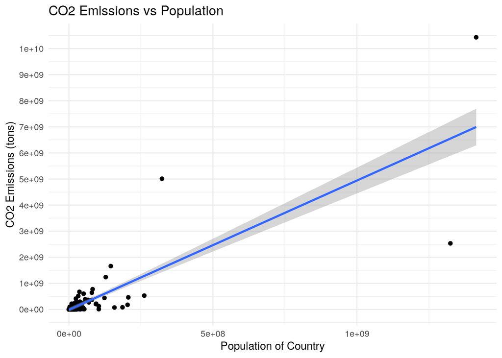

```r
ggplot(joined_data, aes(x = Population, y = CO2Emissions)) +
    geom_point() + ggtitle("CO2 Emissions vs Population") + xlab("Population of Country") +
    scale_y_continuous(name = "CO2 Emissions (tons)", breaks = seq(0,
        1e+11, 1e+09)) + geom_smooth(method = "lm") + theme_minimal()
```

Plot 1 depicts the relationship between the population of a country and the CO2 emissions in a scatterplot. In theory, the more people are present in a country, the greater the amount of carbon emissions. However, as seen in the graph, this proposed relationship is heavily influenced by outliers. Countries with very large populations such as China or India seem to pull the distribution significantly to the point where they cancel out. However, although the distribution seems to fan out, there appears to be a slight positive relationship between a country’s population and their carbon emissions. This is further supported by the utilization of geom_smooth(), which provides a shaded area that signifies the 95% confidence interval of the linear regression line. Though a country’s population should not and cannot be controlled via forceful means, this graph is a good indicator of how our increasing global population will only raise carbon emissions, which only provides more urgency to stop this rapid increase.

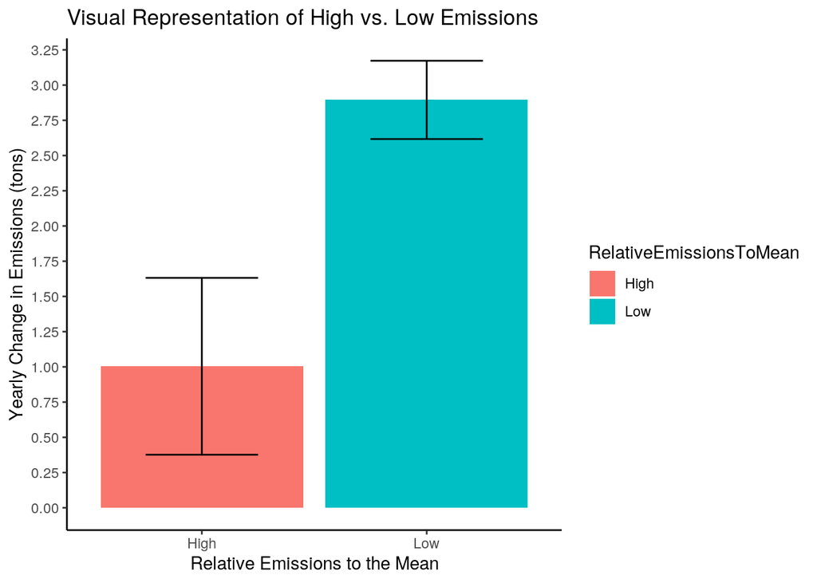

```r
# your plot 2
ggplot(joined_data, aes(x = RelativeEmissionsToMean, y = YearlyChange,
    fill = RelativeEmissionsToMean)) + geom_bar(aes(y = YearlyChange),
    stat = "summary", fun = mean) + ggtitle("Visual Representation of High vs. Low Emissions") +
    xlab("Relative Emissions to the Mean") + scale_y_continuous(name = "Yearly Change in Emissions (tons)",
    breaks = seq(0, 3.25, 0.25)) + theme_classic() + geom_errorbar(stat = "summary",
    fun.data = mean_se, width = 0.5)
```

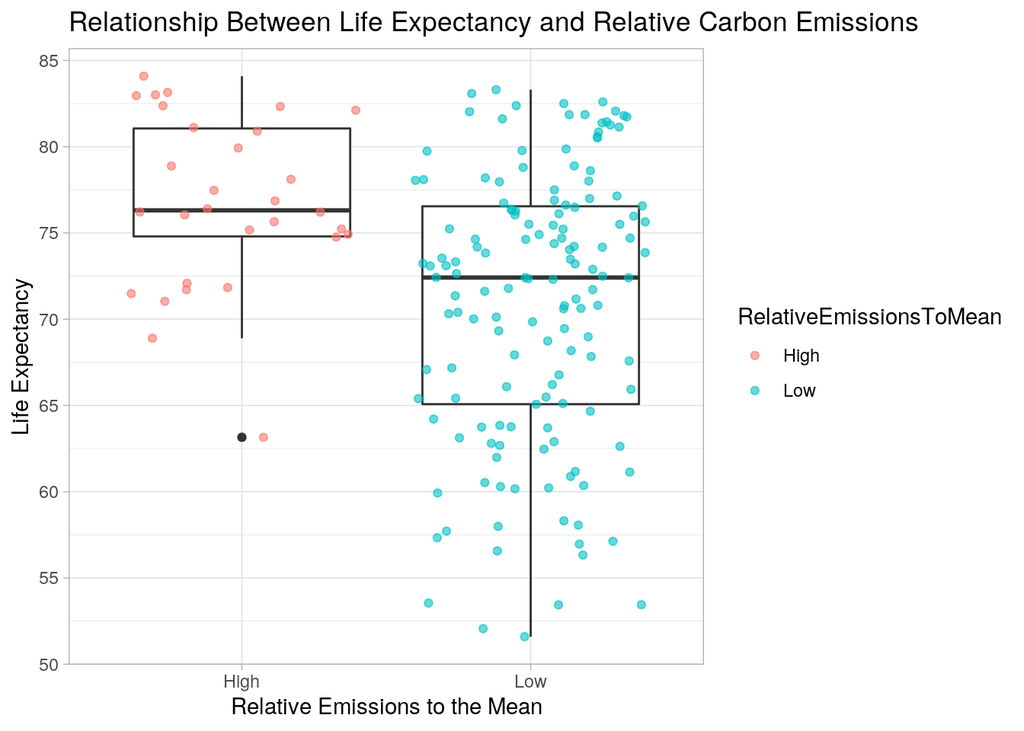

```r
# your plot 3
ggplot(joined_data, aes(x = RelativeEmissionsToMean, y = LifeExpectancy)) +
    geom_boxplot() + geom_jitter(alpha = 0.6, aes(color = RelativeEmissionsToMean)) +
    xlab("Relative Emissions to the Mean") + scale_y_continuous(name = "Life Expectancy",
    breaks = seq(0, 100, 5)) + theme_light() + ggtitle("Relationship Between Life Expectancy and Relative Carbon Emissions")
```

The final graph created was a boxplot between relative emissions and life expectancy in order to gauge the health effects of carbon emissions on people around the world. As seen in the graph above, countries with higher relative emissions appear to have a higher life expectancy than those with lower relative emissions. This supports the notion that more developed countries typically have longer life expectancies. However, one cause for concern is the wide range of nations with lower emissions. Using geom_jitter(), the points of each country was plotted on top of the scatterplot. Here, it can be seen that there is almost a normal distribution of life expectancies in this category. It can be assumed that there are other factors that play into these diverse values, so future studies on carbon emissions and health effects should be investigated. It should be noted that the `High` category included the only outlier, which may or may not have influenced the box plot. This is additional cause for further investigation.

#### Concluding Remarks

In conclusion, the data above tends to suggest that carbon emissions pose various effects upon the world. My initial predictions were only partly supported by the data, but further investation is warranted. Though these effects cannot be proven to be directly caused by such emissions, it is interesting to consider the possibilities at hand. With these considerations, a deeper look into the dangers of carbon emissions should be performed.